### ECE 225B: Universal Probability and Applications @UCSD

http://circuit.ucsd.edu/~yhk/ece225b-spr18/

# (Solutions) Homework 1: Lempel-Ziv probability assignment and universal compression

- **Due: May 8, 2018, 12:00 AM**
- Late homework will never be accepted.
- The homework will be collected through Gradescope. Please follow the submission instruction on Piazza.
- Please read the following problems carefully, and **write down your code as clearly as possible and add suitable comments.**
- **NAME**: Jongha Ryu (TA)
- **PID**:

In this homework, we explore the Lempel-Ziv (LZ) probability assignment, which is based on the LZ78 compression scheme (Ziv and Lempel, 1978).

- Jacob Ziv, and Abraham Lempel. **"Compression of individual sequences via variable-rate coding."** *IEEE transactions on Information Theory* 24.5 (1978): 530-536. doi:10.1109/TIT.1978.1055934.

We will first implement the LZ probability assignment, and verify its mean universality. Then, we will plug-in the probability assignment to the arithmetic encoder to compress some real-world data.

```python
import numpy as np
import matplotlib.pyplot as plt
%matplotlib inline
```

## Problem 1. (LZ probability assignment)

### Problem 1(a).

Write a function

```
prob_LZ78_seq(string, char_to_index)
```

where

- Inputs
  - `string`: `str`, an input string of symbols ;
  - `char_to_index`: `dict`, a mapping from characters to indices;
- Outputs
  - `dist_array`, the vertical stack of LZ sequential probability assignments. That is, `dist_array[i]`$=q_{\text{LZ}}(\cdot|x^{i})$, for $i=0,\ldots,n$, if the input string is $x^n=(x_1,\ldots,x_{n})$

For example, the function should output the following examples correctly:

```
>>> A = '10111111'
>>> prob_LZ78_seq(A, chars_to_dict('01'))
array([[ 0.5       ,  0.5       ],
       [ 0.33333333,  0.66666667],
       [ 0.5       ,  0.5       ],
       [ 0.5       ,  0.5       ],
       [ 0.4       ,  0.6       ],
       [ 0.33333333,  0.66666667],
       [ 0.5       ,  0.5       ],
       [ 0.33333333,  0.66666667],
       [ 0.25      ,  0.75      ]])
>>> B = '0010110111'
>>> prob_LZ78_seq(B, chars_to_dict('01'))
array([[ 0.5       ,  0.5       ],
       [ 0.66666667,  0.33333333],
       [ 0.5       ,  0.5       ],
       [ 0.75      ,  0.25      ],
       [ 0.33333333,  0.66666667],
       [ 0.5       ,  0.5       ],
       [ 0.8       ,  0.2       ],
       [ 0.25      ,  0.75      ],
       [ 0.33333333,  0.66666667],
       [ 0.5       ,  0.5       ],
       [ 0.83333333,  0.16666667]])
>>> prob_LZ78_seq(B, chars_to_dict('012'))
array([[ 0.33333333,  0.33333333,  0.33333333],
       [ 0.6       ,  0.2       ,  0.2       ],
       [ 0.33333333,  0.33333333,  0.33333333],
       [ 0.71428571,  0.14285714,  0.14285714],
       [ 0.2       ,  0.6       ,  0.2       ],
       [ 0.33333333,  0.33333333,  0.33333333],
       [ 0.77777778,  0.11111111,  0.11111111],
       [ 0.14285714,  0.71428571,  0.14285714],
       [ 0.2       ,  0.6       ,  0.2       ],
       [ 0.33333333,  0.33333333,  0.33333333],
       [ 0.81818182,  0.09090909,  0.09090909]])
>>> C = '00121212102101210'
>>> prob_LZ78_seq(C, chars_to_dict('012'))
array([[ 0.33333333,  0.33333333,  0.33333333],
       [ 0.6       ,  0.2       ,  0.2       ],
       [ 0.33333333,  0.33333333,  0.33333333],
       [ 0.71428571,  0.14285714,  0.14285714],
       [ 0.55555556,  0.11111111,  0.33333333],
       [ 0.45454545,  0.27272727,  0.27272727],
       [ 0.33333333,  0.33333333,  0.33333333],
       [ 0.38461538,  0.23076923,  0.38461538],
       [ 0.2       ,  0.6       ,  0.2       ],
       [ 0.33333333,  0.33333333,  0.33333333],
       [ 0.33333333,  0.2       ,  0.46666667],
       [ 0.14285714,  0.71428571,  0.14285714],
       [ 0.6       ,  0.2       ,  0.2       ],
       [ 0.33333333,  0.33333333,  0.33333333],
       [ 0.29411765,  0.17647059,  0.52941176],
       [ 0.11111111,  0.77777778,  0.11111111],
       [ 0.71428571,  0.14285714,  0.14285714],
       [ 0.2       ,  0.6       ,  0.2       ]])
>>> D = 'AGTTTTCGTAACGTT'
>>> prob_LZ78_seq(D, chars_to_dict('AGTC'))
array([[ 0.25      ,  0.25      ,  0.25      ,  0.25      ],
       [ 0.57142857,  0.14285714,  0.14285714,  0.14285714],
       [ 0.4       ,  0.1       ,  0.4       ,  0.1       ],
       [ 0.30769231,  0.07692308,  0.30769231,  0.30769231],
       [ 0.25      ,  0.25      ,  0.25      ,  0.25      ],
       [ 0.25      ,  0.0625    ,  0.25      ,  0.4375    ],
       [ 0.14285714,  0.14285714,  0.14285714,  0.57142857],
       [ 0.21052632,  0.05263158,  0.21052632,  0.52631579],
       [ 0.25      ,  0.25      ,  0.25      ,  0.25      ],
       [ 0.18181818,  0.04545455,  0.31818182,  0.45454545],
       [ 0.25      ,  0.25      ,  0.25      ,  0.25      ],
       [ 0.28      ,  0.04      ,  0.28      ,  0.4       ],
       [ 0.25      ,  0.14285714,  0.25      ,  0.35714286],
       [ 0.14285714,  0.14285714,  0.14285714,  0.57142857],
       [ 0.25      ,  0.25      ,  0.25      ,  0.25      ],
       [ 0.22580645,  0.12903226,  0.32258065,  0.32258065]])
```

Recall that if a sequence $x^n$ can be parsed as $y^cy_{\text{last}}$, then $$ q_{\text{LZ}}(x^n) =q_{\text{LZ}}(y^cy_{\text{last}}) =\prod_{i=1}^c q_{\text{LZ}}(y_i|y^{i-1}) \cdot q_{\text{LZ}}(y_{\text{last}}|y^c), % =\prod_{i=1}^c \frac{1}{(M-1)i+1} \cdot q_{\text{LZ}}(y_{\text{last}}|y^c), % = \frac{1}{(c+1)!} \quad(\text{for binary alphabet; }M=2) $$ where $$ q_{\text{LZ}}(y_i|y^{i-1}) = \frac{1}{(M-1)i+1}, $$ and $$ q_{\text{LZ}}(y_{\text{last}}|y^c) = \frac{\text{# of words with prefix }y_{\text{last}}\text{ in the word pool}}{\text{# of words in the word pool}}. $$

However, in this problem, **you are required to find $q_{\text{LZ}}(\cdot|x^{j-1})$ for each $j=1,\ldots,n+1$.**

```python
# You may find this function useful
def chars_to_dict(chars):
    chars = sorted(list(set(chars)))
    char_to_index  = {x: i for i, x in enumerate(chars)}

    return char_to_index
```

### Solution to #1(a).

```python
class Node(object):
    def __init__(self, data=None):
        self.data = data
        self.children = []

    def add_child(self):
        self.children.append(Node(self))

    def add_children(self, num_child):
        for _ in range(num_child):
            self.add_child()
```

```python
def prob_LZ78_seq(string, char_to_index):
    """
    - string: str, a sequence to be parsed
    - char_to_index: dict, a dictionary which maps a character to its index
    """
    num_abc = len(char_to_index)
    dist_array = np.zeros((len(string)+1, num_abc))  # i-th row is the sequential distribution

    root = Node(None)
    root.add_children(num_abc)
    root.data = np.ones(num_abc)
    node = root

    for i in range(len(string)):
        dist_array[i] = node.data

        new_symbol_index = char_to_index[string[i]]
        next_node = node.children[new_symbol_index]
        node.data[new_symbol_index] += num_abc-1

        if next_node.children: # if next_node is not a leaf
            node = next_node

        else: # if next_node is a leaf
            next_node.add_children(num_abc)
            next_node.data = np.ones(num_abc)
            node = root

    dist_array[-1] = node.data # q_{LZ}(x_{n+1}|x^n)
    dist_array /= dist_array.sum(axis=1)[:, np.newaxis] # normalization

    return dist_array
```

#### Examples

```python
A = '10111111'
B = '0010110111'
C = '00121212102101210'
D = 'AGTTTTCGTAACGTT'
```

```python
prob_LZ78_seq(A, chars_to_dict('01'))
```

```
array([[0.5       , 0.5       ],
       [0.33333333, 0.66666667],
       [0.5       , 0.5       ],
       [0.5       , 0.5       ],
       [0.4       , 0.6       ],
       [0.33333333, 0.66666667],
       [0.5       , 0.5       ],
       [0.33333333, 0.66666667],
       [0.25      , 0.75      ]])
```

```python
prob_LZ78_seq(B, chars_to_dict('01'))
```

```
array([[0.5       , 0.5       ],
       [0.66666667, 0.33333333],
       [0.5       , 0.5       ],
       [0.75      , 0.25      ],
       [0.33333333, 0.66666667],
       [0.5       , 0.5       ],
       [0.8       , 0.2       ],
       [0.25      , 0.75      ],
       [0.33333333, 0.66666667],
       [0.5       , 0.5       ],
       [0.83333333, 0.16666667]])
```

```python
prob_LZ78_seq(B, chars_to_dict('012'))
```

```
array([[0.33333333, 0.33333333, 0.33333333],
       [0.6       , 0.2       , 0.2       ],
       [0.33333333, 0.33333333, 0.33333333],
       [0.71428571, 0.14285714, 0.14285714],
       [0.2       , 0.6       , 0.2       ],
       [0.33333333, 0.33333333, 0.33333333],
       [0.77777778, 0.11111111, 0.11111111],
       [0.14285714, 0.71428571, 0.14285714],
       [0.2       , 0.6       , 0.2       ],
       [0.33333333, 0.33333333, 0.33333333],
       [0.81818182, 0.09090909, 0.09090909]])
```

```python
prob_LZ78_seq(C, chars_to_dict('012'))
```

```
array([[0.33333333, 0.33333333, 0.33333333],
       [0.6       , 0.2       , 0.2       ],
       [0.33333333, 0.33333333, 0.33333333],
       [0.71428571, 0.14285714, 0.14285714],
       [0.55555556, 0.11111111, 0.33333333],
       [0.45454545, 0.27272727, 0.27272727],
       [0.33333333, 0.33333333, 0.33333333],
       [0.38461538, 0.23076923, 0.38461538],
       [0.2       , 0.6       , 0.2       ],
       [0.33333333, 0.33333333, 0.33333333],
       [0.33333333, 0.2       , 0.46666667],
       [0.14285714, 0.71428571, 0.14285714],
       [0.6       , 0.2       , 0.2       ],
       [0.33333333, 0.33333333, 0.33333333],
       [0.29411765, 0.17647059, 0.52941176],
       [0.11111111, 0.77777778, 0.11111111],
       [0.71428571, 0.14285714, 0.14285714],
       [0.2       , 0.6       , 0.2       ]])
```

```python
prob_LZ78_seq(D, chars_to_dict('AGTC'))
```

```
array([[0.25      , 0.25      , 0.25      , 0.25      ],
       [0.57142857, 0.14285714, 0.14285714, 0.14285714],
       [0.4       , 0.1       , 0.4       , 0.1       ],
       [0.30769231, 0.07692308, 0.30769231, 0.30769231],
       [0.25      , 0.25      , 0.25      , 0.25      ],
       [0.25      , 0.0625    , 0.25      , 0.4375    ],
       [0.14285714, 0.14285714, 0.14285714, 0.57142857],
       [0.21052632, 0.05263158, 0.21052632, 0.52631579],
       [0.25      , 0.25      , 0.25      , 0.25      ],
       [0.18181818, 0.04545455, 0.31818182, 0.45454545],
       [0.25      , 0.25      , 0.25      , 0.25      ],
       [0.28      , 0.04      , 0.28      , 0.4       ],
       [0.25      , 0.14285714, 0.25      , 0.35714286],
       [0.14285714, 0.14285714, 0.14285714, 0.57142857],
       [0.25      , 0.25      , 0.25      , 0.25      ],
       [0.22580645, 0.12903226, 0.32258065, 0.32258065]])
```

### Problem 1(b).

Based on (a), write a function

```
log2_prob_LZ78(string, char_to_index)
```

that outputs $\log_2 q_{\text{LZ}}(x^{n})$ given the input string $x^n$. For example,

```
>>> A = '10111111'
>>> log2_prob_LZ78(A, chars_to_dict('01'))
-7.4918530963296748
>>> B = '0010110111'
>>> log2_prob_LZ78(B, chars_to_dict('01'))
-6.9068905956085178
>>> log2_prob_LZ78(B, chars_to_dict('012'))
-9.8841705191084355
>>> C = '00121212102101210'
>>> log2_prob_LZ78(C, chars_to_dict('012'))
-22.716467197858318
>>> D = 'AGTTTTCGTAACGTT'
>>> log2_prob_LZ78(D, chars_to_dict('AGTC'))
-33.988292978999269
```

Be careful with underflow of small probabilities (or overflow).

### Solution to #1(b).

```python
def log2_prob_LZ78(string, char_to_index):
    """
    - string: str, a sequence to be parsed
    - char_to_index: dict, a dictionary which maps a character to its index
    """
    dist_array = prob_LZ78_seq(string, char_to_index)
    log2prob = np.sum([np.log2(dist_array[i, char_to_index[string[i]]]) for i in range(len(string))])

    return log2prob
```

#### Examples

```python
A, log2_prob_LZ78(A, chars_to_dict('01'))
```

```
('10111111', -7.491853096329675)
```

```python
B, log2_prob_LZ78(B, chars_to_dict('01'))
```

```
('0010110111', -6.906890595608519)
```

```python
B, log2_prob_LZ78(B, chars_to_dict('012'))
```

```
('0010110111', -9.884170519108435)
```

```python
C, log2_prob_LZ78(C, chars_to_dict('012'))
```

```
('00121212102101210', -22.716467197858318)
```

```python
D, log2_prob_LZ78(D, chars_to_dict('AGTC'))
```

```
('AGTTTTCGTAACGTT', -33.98829297899927)
```

## Problem 2. (Minimax mean universality)

In this problem, we will verify the *mean universality* of the LZ probability distribution implemented in Problem 1. In the class we learned that $$ \lim_{n\to\infty}\mathbb{E}_{X^n\sim \mathsf{P}}\left[\log_2\frac{p(X^n)}{q_{\text{LZ}}(X^n)}\right]=0 $$ for any stationary ergodic measure $\mathsf{P}$. To verify this, we draw $(X_{1}(i),\ldots,X_{n}(i))\sim \mathsf{P}$ independently for $i=1,\ldots,N$ to obtain $$ \frac{1}{N}\sum_{i=1}^N \log_2\frac{p(X^n(i))}{q_{\text{LZ}}(X^n(i))}\approx \mathbb{E}_{X^n\sim \mathsf{P}}\left[\log\frac{p(X^n)}{q_{\text{LZ}}(X^n)}\right]. $$ For $N$ sufficiently large, the sample average on the (LHS) would be close to the expected regret on the (RHS). We will consider the following two simple probability model classes.

> a) $\mathcal{P_a}$={a Bernoulli($p$) i.i.d. process $X_i\sim \text{Bern}(p)$: $p\in[0,1]$}

> b) $\mathcal{P_b}$={a binary symmetric Markov chain $X^n$ of transition matrix $$ P=\begin{bmatrix} 1-p & p\\ p & 1-p \end{bmatrix}, $$ starting from the initial distribution $\pi=[1/2,1/2]$: $p\in[0,1]$}

For each model class, plot $\log_{10} n$ versus for $p \in \{0.02,0.04,\ldots,0.5\}$ the logarithm of $$ \frac{1}{n}\max_{p_i}\frac{1}{N}\sum_{i=1}^N \log_2\frac{p(X_{(i)}^n)}{q_{\text{LZ}}(X_{(i)}^n)} $$ to the base $10$ for $n\in \{10, 50, 100, 500, 1000, 5000, 10000\}$, while fixing $N=50$.

Plot the two curves for each model class in the same plot. For which model does the LZ probability give a faster convergence?

**Hint:** You may want to implement following functions first.

- `draw_one_sample_from(pmf)` outputs a random number from `{0,...,len(pmf)-1}` according to the given `pmf`.

  For example,

  ```
  >>> draw_one_sample_from([0.8, 0.2])
    0
  ```

- `generate_mc(n, P, pinit)` outputs `(x,log2_prob)`, where
  - `x` is a sequence of Markov chain of length `n` drawn according to the given transition matrix `P` starting from the initial distribution `pinit`, and
  - `log2_prob` is the log probability of the sequence to the base 2.

    For example,

    ```
    >>> generate_mc(10, np.array([[0.3,0.7],[0.7,0.3]]))
    (array([1, 0, 0, 1, 0, 0, 0, 0, 0, 1]), -11.743120662150064)
    ```

Note that you can generate an iid source using the function `generate_mc`.

## Solution to #2.

```python
def draw_one_sample_from(pmf):
    pmf = np.array(pmf)
    pmf = pmf / sum(pmf)
    return np.random.choice(range(len(pmf)), p=pmf)

def generate_mc(n, P, pinit=None):
    '''
    - n: length of output sequence
    - P: transition matrix
    - pinit: initial distribution
    '''
    x = np.zeros(n, dtype=np.int)
    log2_prob = 0
    if pinit is None:
        x[0] = np.random.randint(P.shape[0])
        p0 = 1/P.shape[0]
    else:
        x[0] = draw_one_sample_from(pinit)
        p0 = pinit[x[0]]
    log2_prob += np.log2(p0)

    for i in range((int(n)-1)):
        x[i+1] = draw_one_sample_from(P[x[i], :])
        log2_prob += np.log2(P[x[i],x[i+1]])

    return x, log2_prob
```

```python
def mean_redundancy(nlist, plist, N=50, model="iid"):
    M = 2  # let's focus on the binary alphabet
    red_array = np.zeros((len(plist), len(nlist)))

    for i, p in enumerate(plist):
        if model == "iid":
            P = np.array([[1-p, p], [1-p, p]])
            pinit = [1-p, p]
        elif model == "bsmc":
            P = np.array([[1-p, p], [p, 1-p]])
            pinit = None
        else:
            raise ValueError("Input a valid model class either 'iid' or 'bsmc'")

        for j, n in enumerate(nlist):
            print('model={}, n={}, {}-th p={}'.format(model,n,i+1,p))
            redundancy = 0
            for _ in range(N):
                x, log2prob = generate_mc(n, P, pinit)
                xstr = ''.join([str(xi) for xi in x])
                log2probLZ78 = log2_prob_LZ78(xstr, chars_to_dict([str(k) for k in range(M)]))
                redundancy += log2prob - log2probLZ78
            red_array[i,j] = redundancy/N/n

    return red_array
```

```python
nlist = [10, 50, 100, 500, 1000, 5000, 10000]
plist = np.arange(0.02, 0.51, 0.02)
%time red_array_iid =  mean_redundancy(nlist, plist, model="iid")
%time red_array_bsmc = mean_redundancy(nlist, plist, model="bsmc")
```

[output not shown]

[output cut: 297 more lines]

```
model=bsmc, n=10, 24-th p=0.48000000000000004
model=bsmc, n=50, 24-th p=0.48000000000000004
model=bsmc, n=100, 24-th p=0.48000000000000004
model=bsmc, n=500, 24-th p=0.48000000000000004
model=bsmc, n=1000, 24-th p=0.48000000000000004
model=bsmc, n=5000, 24-th p=0.48000000000000004
model=bsmc, n=10000, 24-th p=0.48000000000000004
model=bsmc, n=10, 25-th p=0.5
model=bsmc, n=50, 25-th p=0.5
model=bsmc, n=100, 25-th p=0.5
model=bsmc, n=500, 25-th p=0.5
model=bsmc, n=1000, 25-th p=0.5
model=bsmc, n=5000, 25-th p=0.5
model=bsmc, n=10000, 25-th p=0.5
Wall time: 15min 2s
```

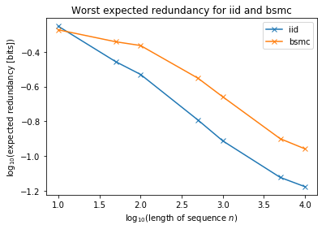

```python
plt.plot(np.log10(nlist), np.log10(red_array_iid.max(axis=0)), marker='x', label='iid')
plt.plot(np.log10(nlist), np.log10(red_array_bsmc.max(axis=0)), marker='x', label='bsmc')
plt.title('Worst expected redundancy for iid and bsmc')
plt.xlabel('$\log_{10}$(length of sequence $n$)')
plt.ylabel('$\log_{10}$(expected redundancy [bits])')
plt.legend(loc=1)
```

Since the bsmc model is definitely a larger class than the iid model, LZ learns iid much faster as one can expect!

## Problem 3. (Universal compression using arithmetic encoder)

In this problem, we will implement a universal compression scheme based on the LZ probability assignment. In the following, we provide a complete Python 3 code for a simple offline version of the *arithmetic encoder*. Later in this course, you will learn this coding scheme in detail. Briefly speaking, given a sequential probability model $q(\cdot|x^{i-1})$, the arithmetic encoder maps a string $x^n$ into a real number between 0 and 1 in a binary representation, and it only requires $\left\lceil\log_2 \frac{1}{q(x^n)}\right\rceil +1$ bits to encode $x^n$. The best advantage of the arithmetic coding is that it allows us to separate modeling and compression. **Hence, by plugging-in any (universal) sequential probability model to the arithmetic encoder, we have a corresponding (universal) compression scheme!**

[figure not shown]

For simplicity, the following version of the arithmetic encoder takes a stack of sequential distributions as inputs. Hence in this problem, to encode a string $x^n$ using the LZ probability assignment $q_{\text{LZ}}$, instead of providing a sequential probability assignment model, you first need to find a stack of sequential distributions by scanning the sequence once, and then pass it to the arithmetic encoder.

(**NOTE.** Our resulting compression scheme (LZ probability assignment + arithmetic encoder) is *different* from the original LZ78 compression algorithm. In the original algorithm, the code bits can be generated directly from the parsing.)

#### Arithmetic encoder implementation

- References (mostly adapted from the second reference)
  - Witten, Ian H., Radford M. Neal, and John G. Cleary. "Arithmetic coding for data compression." Communications of the ACM 30.6 (1987): 520-540. (the most famous reference)
  - http://www.drdobbs.com/cpp/data-compression-with-arithmetic-encodin/240169251 (a complete C++ implementation)
  - https://github.com/nayuki/Reference-arithmetic-coding (an incomplete Python implementation)
  - http://www.inference.org.uk/mackay/python/compress/ac/ac_encode.py (David MacKay's Python implementation for binary sources)

```python
'''
**************************
**************************
*** ARITHMETIC ENCODER ***
**************************
**************************
'''
def arithmetic_enc_offline(string, char_to_index, pmfs, STATE_SIZE=32):
    ZERO = 0
    ONE = (1 << STATE_SIZE) - 1
    ONE_FOURTH = 1 << (STATE_SIZE - 2)
    HALF = ONE_FOURTH * 2
    THREE_FOURTH = HALF + ONE_FOURTH
    # Mask of STATE_SIZE ones, i.e., 111...111.
    MASK = ONE
    # Mask of the top bit at width STATE_SIZE, i.e., 100...000.
    TOP_MASK = HALF
    # Mask of the second highest bit at width STATE_SIZE, i.e., 010...000.
    SECOND_MASK = TOP_MASK >> 1

    low, high = ZERO, ONE
    low_float, high_float = 0.0, 1.0
    encoded_bits = ''
    num_pending_bits = 0

    for i, symbol in enumerate(string):
        curr_cmf = np.hstack(([0], np.cumsum(pmfs[i])))
        curr_idx = char_to_index[symbol]

        p_prev_symb = high - low + 1 # range

        high = int(low + p_prev_symb*curr_cmf[curr_idx+1] / curr_cmf[-1]) - 1
        low  = int(low + p_prev_symb*curr_cmf[curr_idx]   / curr_cmf[-1])

        # To check the validity of logic
        p_prev_symb_float = high_float - low_float
        high_float = low_float + p_prev_symb_float*curr_cmf[curr_idx+1] / curr_cmf[-1]
        low_float  = low_float + p_prev_symb_float*curr_cmf[curr_idx]   / curr_cmf[-1]

        assert ZERO <= low
        assert low  < high
        assert high <= ONE

        while 1:
            if (low ^ high) & TOP_MASK == 0:  # if MSBs are equal
                bit = 0 if high & TOP_MASK == 0 else 1
                encoded_bits += output_bit_plus_pending(bit, num_pending_bits)
                num_pending_bits = 0
                low  =  (low  << 1) & MASK
                high = ((high << 1) & MASK) | 1

                assert ZERO <= low < high <= ONE, (ZERO<=low, high<=ONE, bin_in_bits(low,STATE_SIZE), bin_in_bits(high,STATE_SIZE))

            elif (low & SECOND_MASK) != 0 and (high & SECOND_MASK) == 0:  # if low=01... and high=10...
                num_pending_bits += 1
                low  = ( (low  ^ SECOND_MASK) << 1)       & MASK         # flip the second MSB and shift in 0 left
                high = (((high ^ SECOND_MASK) << 1) | 1) & MASK   # flip the second MSB and shift in 1 left

                assert ZERO <= low < high <= ONE, (ZERO<=low, high<=ONE, bin_in_bits(low,STATE_SIZE), bin_in_bits(high,STATE_SIZE))
            else:
                break

    # Terminate: adapted from David MacKay's code
    if (HALF-low) > (high-HALF):
        w = HALF-low
        bit = 0
    else:
        w = high-HALF
        bit = 1

    encoded_bits += output_bit_plus_pending(bit, num_pending_bits)
    num_pending_bits = 0
    while w < HALF:
        encoded_bits += str(1-bit)
        w *= 2

    return encoded_bits

def output_bit_plus_pending(bit, num_pending_bits):
    assert bit in {0, 1}
    return str(bit) + num_pending_bits * str(1-bit)
```

The following is a wrapper of the arithmetic encoder to compress a string using LZ probability that you can use in the following problems.

```python
def compress_with_LZ_prob(string, char_to_index):
    pmfs = prob_LZ78_seq(string, char_to_index)
    return arithmetic_enc_offline(string, char_to_index, pmfs)
```

### Problem 3(a). Binary symmetric Markov chain

Generate a random sequence of length $n=10000$ from the binary symmetric Markov chain of parameter $p\in \{0.02, 0.04, \ldots, 0.48\}$, and compress the sequence using `compress_with_LZ_prob`. Repeat the experiment $N=50$ times for each $p$ and take an average. Can you compare this number with the fundamental limit of the lossless compression of this source? Plot the fundamental limit of the compression and the average of compression ratios for each $p$ in the same plot.

```python
n = 1000
N = 10
plist = np.arange(0.02, 0.5, 0.02)
compress_ratio_list = np.zeros(len(plist))
for i, p in enumerate(plist):
    P = np.array([[1-p, p], [p, 1-p]])
    print("For p={}".format(p))
    for _ in range(N):
        x, log2prob = generate_mc(n, P)
        xstr = ''.join([str(xi) for xi in x])
        encoded_bits = compress_with_LZ_prob(xstr, chars_to_dict('01'))
        compress_ratio_list[i] += len(encoded_bits) / n
compress_ratio_list /= N
```

[output not shown]

```python
def bin_entropy(p):
    assert 0 <= p <= 1
    return -p*np.log2(p)-(1-p)*np.log2(1-p)
```

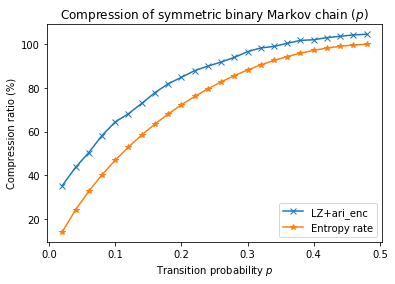

```python
plt.plot(plist, compress_ratio_list*100, label="LZ+ari_enc", marker='x')
plt.plot(plist, [bin_entropy(p)*100 for p in plist], label="Entropy rate", marker='*')
plt.title('Compression of symmetric binary Markov chain ($p$)')
plt.xlabel('Transition probability $p$')
plt.ylabel('Compression ratio (%)')
plt.legend(loc=4)
```

The fundamental limit of the lossless compression is the entropy rate $\overline{H}$, and the entropy rate reduces to the binary entropy function $H(p)$ for the bsmc source. The plot shows that our universal compression algorithm gives a similar behavior compared to the binary entropy function as $p$ varies. If the sample size goes to infinity, the performance should converge to the entropy rate.

For part (b) and (c), find the compression ratio of the number of compressed bits of a sequence of length $n$ with respect to a uniform encoding which maps a character from an alphabet of size $M$ to a binary sequence of $n\log_2 M$ bits.

```python
def compress(filename, char_to_index=None):
    file = open(filename, 'r', encoding="utf8")
    string = file.read()
    file.close()
    if char_to_index is None:
        char_to_index = chars_to_dict(string)

    encoded_bits = compress_with_LZ_prob(string, char_to_index)
    compress_ratio = len(encoded_bits) / (len(string) * np.log2(len(char_to_index)))

    print("The compression ratio is {}%.".format(compress_ratio*100))
```

### Problem 3(b). Genome sequence

In the `data` folder you can find `CElegans_sample.txt` that contains the first 2000 symbols from the Chromosome I of C. Elegans.

- Reference: `CE10.2bit` from http://hgdownload.soe.ucsc.edu/goldenPath/ce10/bigZips/

Compress the sequence and find the compression ratio.

```python
%time compress('data/CElegans_sample.txt', chars_to_dict('AGTC'))
```

```
The compression ratio is 86.075%.
Wall time: 37.1 ms
```

Indeed, we can observe that our genome sequence is not well modeled by a stationary ergodic process. This can be verified by considering the compression ratios as we increase the length of the sequence. If the sequence were indeed generated from a stationary ergodic process, as we increase the sample size $n$, the LZ probability should predict the probability more closely. However, the following experiment shows that the approximation gets worse as we increase the sample size!

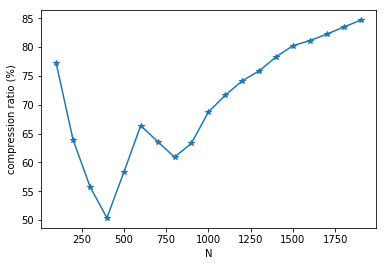

```python
filename = 'data/CElegans_sample.txt'
file = open(filename, 'r', encoding="utf8")
string = file.read()
string = string.upper()
file.close()
char_to_index = chars_to_dict('AGTC')

Nlist = range(100, len(string), 100)
compress_ratio_list = np.zeros(len(Nlist))

for i, N in enumerate(Nlist):
    X = string[:N+1]
    pmfs = prob_LZ78_seq(X, char_to_index)
    encoded_bits = arithmetic_enc_offline(X, char_to_index, pmfs)
    compress_ratio_list[i] = len(encoded_bits) / (len(X) * np.log2(len(char_to_index)))

plt.plot(Nlist, compress_ratio_list * 100, marker="*")
plt.xlabel('N')
plt.ylabel('compression ratio (%)');
```

### Problem 3(c). The Little Prince: Which one is the more efficient language, English or French?

In the `data` folder you can find `sample_the_little_prince_xx.txt` containing the entire text of "The Little Prince" both in French and English (translation).

- References
  - English: https://www.odaha.com/antoine-de-saint-exupery/maly-princ/the-little-prince
  - French: http://gutenberg.net.au/ebooks03/0300771h.html

The texts are preprcessed so that they only contain the blank (' '), and the English alphabets, and/or the French alphabets. Hence, for the English text, we consider an alphabet of size 27. For the French text, with additional 13 characters with accents, we consider an alphabet of size 40.

```python
nums = {'0', '1', '2', '3', '4', '5', '6', '7', '8', '9'}
en_abc = {' ', 'a', 'b', 'c', 'd', 'e', 'f', 'g', 'h', 'i', 'j', 'k', 'l', 'm', 'n',
          'o', 'p', 'q', 'r', 's', 't', 'u', 'v', 'w', 'x', 'y', 'z'}
fr_letters = {'é',
              'à', 'è', 'ù',
              'â', 'ê', 'î', 'ô', 'û',
              'ç',
              'ë', 'ï', 'ü'}
```

```python
def preprocess(filename, lang="EN"):
    '''
    The numbers should be taken care manually.
    '''
    file = open(filename, 'r')
    string = file.read()
    file.close()
    alphabet = nums | en_abc
    if lang == "FR":
        alphabet |= fr_letters

    string = string.lower()

    for char in string:
        if char not in nums | en_abc | fr_letters:
            if char == "'":
                string = string.replace(char, '')
                print("Replaced {} with ''!".format(char))
            else:
                string = string.replace(char, ' ')
                print("Replaced {} with ' '!".format(char))

    for i in range(10):
        string = string.replace('  ', ' ')
```

```python
filename_list = ['data/sample_the_little_prince_en.txt',
                 'data/sample_the_little_prince_fr.txt']
alphabet_list = [en_abc, en_abc|fr_letters]

for filename, alphabet in zip(filename_list, alphabet_list):
    print("For {}:".format(filename), end = '')
    %time compress(filename, chars_to_dict(alphabet))
```

```
For data/sample_the_little_prince_en.txt:The compression ratio is 70.05007790793213%.
Wall time: 2.22 s
For data/sample_the_little_prince_fr.txt:The compression ratio is 65.883785614881%.
Wall time: 2.36 s
```

Which language is more efficient?

The results are as follows:

- English: 70.05% (66.62%)
- French : 65.88% (58.44%)

Hence, French seems to be more efficient than English, at least in writing "The Little Prince"! 😀